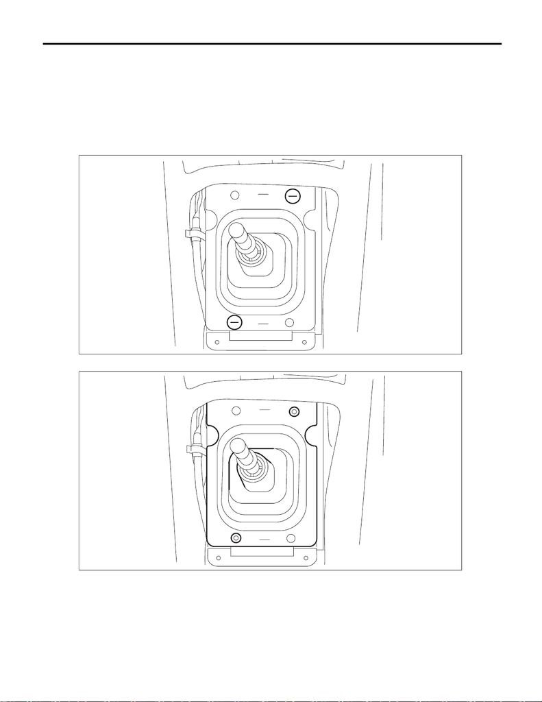

CS-110

Reverse Check Cable

CONTROL SYSTEMS

10.Reverse Check Cable

A: REMOVAL

1) Disconnect the ground cable from battery.

2) Remove the gear shift knob by turning it counterclockwise.

3) Remove the console box assembly. <Ref. to EI-67, REMOVAL, Console Box.>

4) Remove the cover - shift lever. <Ref. to EI-67, REMOVAL, Console Box.>

5) Remove the panel center LWR LH and RH. <Ref. to EI-67, REMOVAL, Console Box.>

6) Remove the clamp.

7) Remove the boot and insulator assembly.

CS-01784

CS-01785

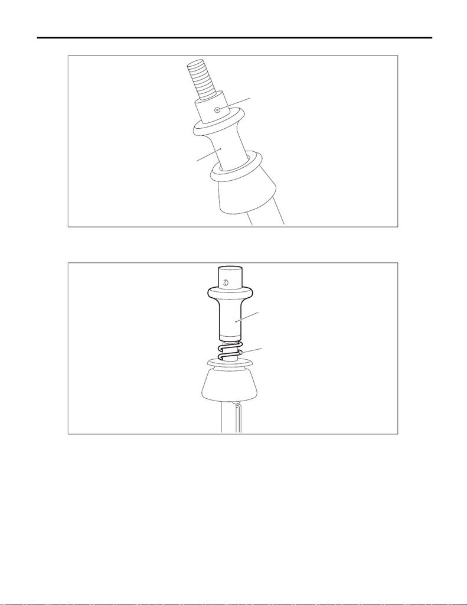

CS-111

Reverse Check Cable

CONTROL SYSTEMS

8) Remove the spring pin from the slider.

9) Remove the slider and spring.

(A) Slider (B) Spring pin

(A) Slider (B) Spring

CS-01795

(A)

(B)

CS-01796

(A)

(B)

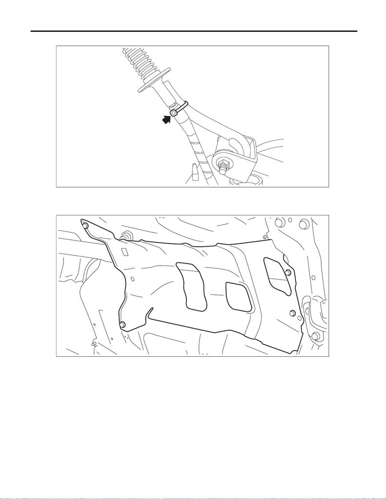

CS-112

Reverse Check Cable

CONTROL SYSTEMS

10) Cut the band clip, and separate the reverse check cable from the gear shift lever.

11) Lift up the vehicle.

12) Remove the center exhaust pipe (rear). <Ref. to EX(STI)-7, REMOVAL, Center Exhaust Pipe.>

13) Remove the center exhaust cover.

14) Remove the crossmember. <Ref. to 6MT(TY85)-29, REMOVAL, Transmission Mounting System.>

CS-01797

CS-01630

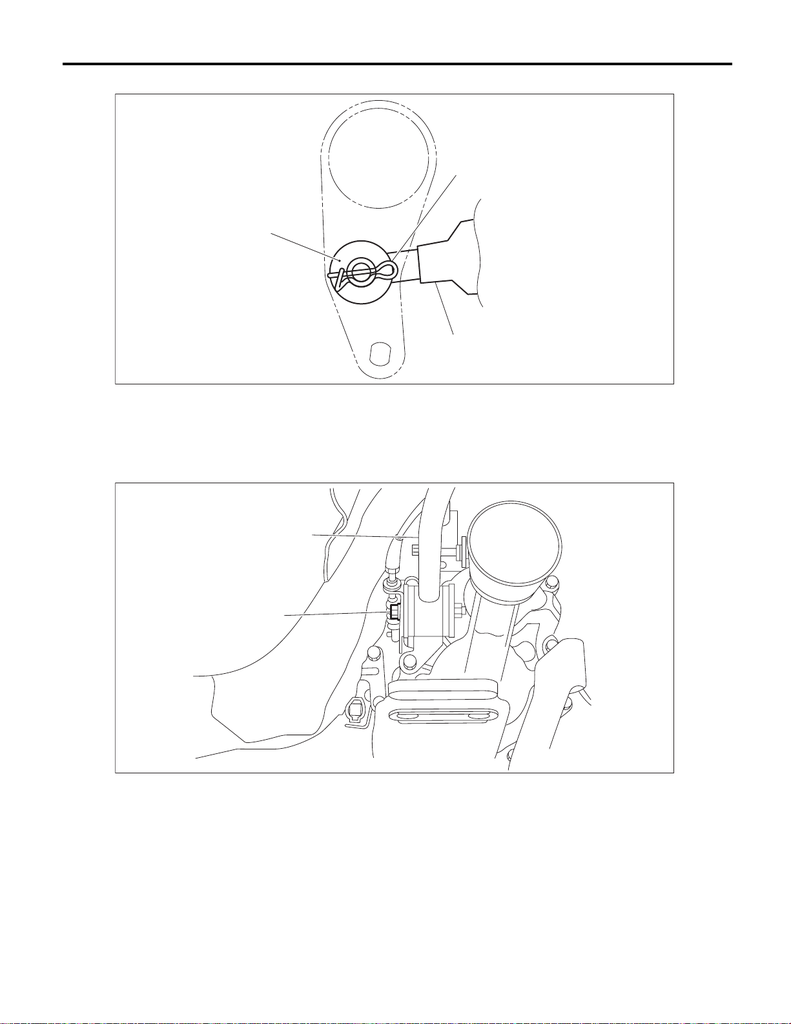

CS-113

Reverse Check Cable

CONTROL SYSTEMS

15) Remove the snap pin and washer, and separate the reverse check cable.

16) Move the transmission to the right side, and remove the stay bolts and the reverse check cable.

NOTE:

If the transmission is not moved aside, the stay bolts may contact the body and cause damage.

(A) Snap pin (B) Washer (C) Reverse check cable

(A) Stay (B) Stay bolt

CS-01788

(B)

(A)

(C)

CS-01815

(A)

(B)

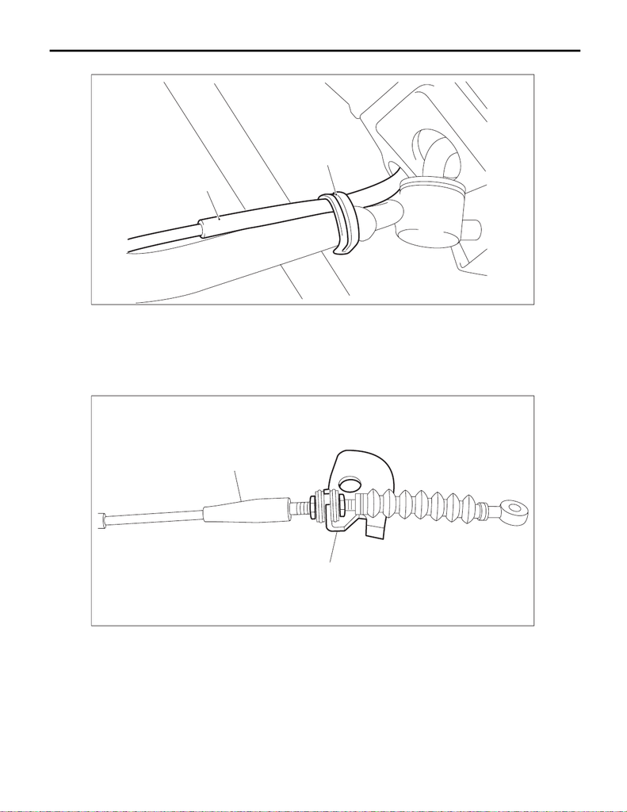

CS-114

Reverse Check Cable

CONTROL SYSTEMS

17) Lift up the stay clip, and separate the stay from the reverse check cable.

18) Pull out the reverse check cable from underside of the vehicle to remove it.

NOTE:

Be careful not to damage the inner boot.

19) Loosen the lock nut, and remove the reverse check cable from the cable plate.

(A) Reverse check cable (B) Clip

(A) Cable plate (B) Reverse check cable

CS-01812

(A)

(B)

CS-01798

(A)

(B)

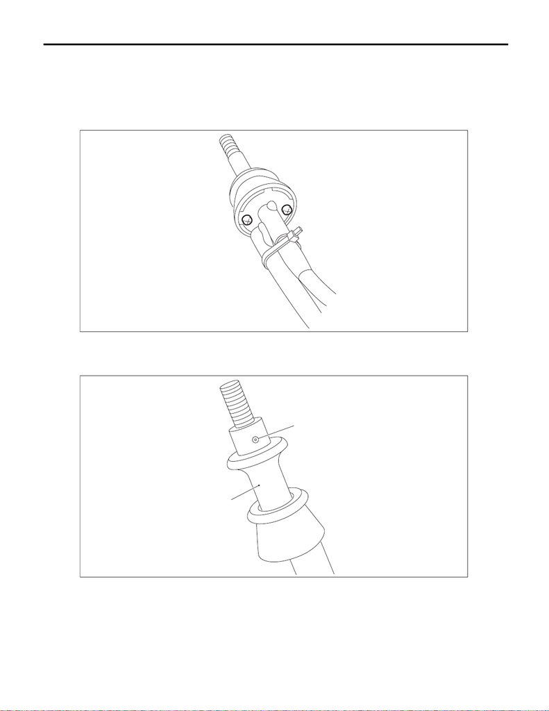

CS-115

Reverse Check Cable

CONTROL SYSTEMS

B: INSTALLATION

1) Insert the reverse check cable into the inner boot hole from underside of the vehicle.

2) Insert the reverse check cable into the gear shift lever assembly, and secure it with the band clip.

NOTE:

• Cut the excess band clip.

• Make sure that the reverse check cable is inserted into the gearshift lever with no gaps.

3) Use the spring pin to secure the end of the slider and reverse check cable.

NOTE:

Apply grease to the moving part of slider.

(A) Slider (B) Spring pin

CS-01816

CS-01795

(A)

(B)

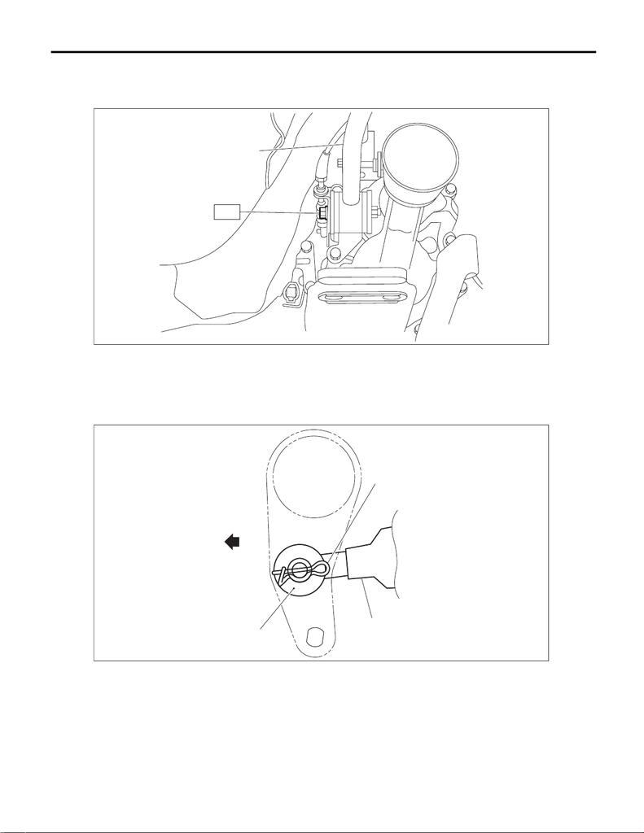

CS-116

Reverse Check Cable

CONTROL SYSTEMS

4) Move the transmission to the right side, and install the stay.

Tightening torque:

T: 32 N·m (3.3 kgf-m, 23.6 ft-lb)

5) Install the reverse check cable, washer and snap pin.

NOTE:

Make sure to point the snap pin in an appropriate direction.

(A) Stay

(A) Reverse check cable (C) Snap pin (D) Front side

(B) Washer

CS-01817

(A)

T

CS-01792

(B)

(D)

(C)

(A)

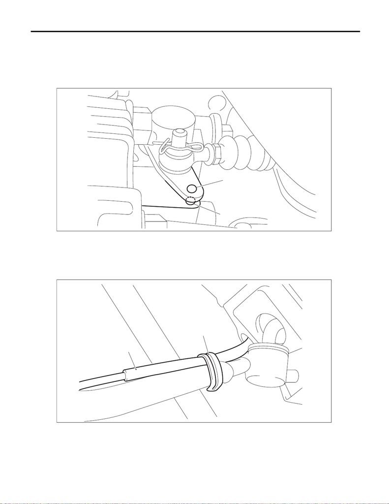

CS-117

Reverse Check Cable

CONTROL SYSTEMS

6) Make sure the hole of extension case is aligned with that of reverse check lever. If the hole positions are

not aligned, adjust the reverse check cable. <Ref. to CS-120, ADJUSTMENT, Reverse Check Cable.>

NOTE:

• Check that the M3 bolt goes through the hole of reverse check lever and can be inserted into the hole of

extension case.

• When checking visually, confirm that the gap of hole positions is 0.5 mm (0.02 in) or less.

7) Secure the reverse check cable to the stay clip.

NOTE:

Install the reverse check cable on top of the stay.

(A) Hole of reverse check lever (B) Hole of extension case

(A) Reverse check cable (B) Clip

CS-01793

(A)

(B)

CS-01812

(A)

(B)

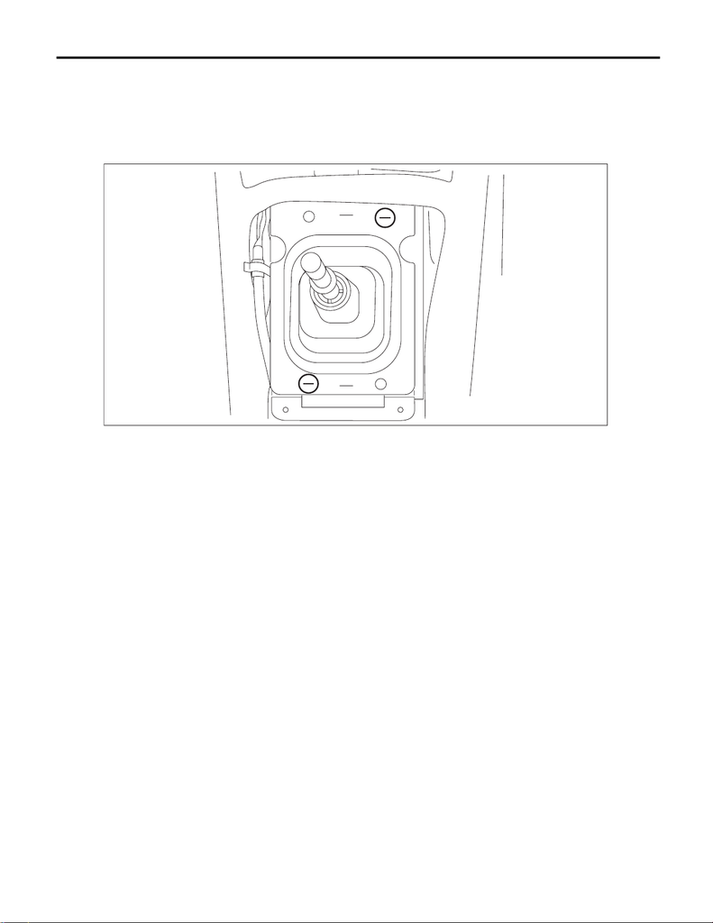

CS-118

Reverse Check Cable

CONTROL SYSTEMS

8) Install the crossmember. <Ref. to 6MT(TY85)-29, INSTALLATION, Transmission Mounting System.>

9) Install the center exhaust cover.

Tightening torque:

18 N·m (1.8 kgf-m, 13.3 ft-lb)

10) Install the center exhaust pipe (rear). <Ref. to EX(STI)-8, INSTALLATION, Center Exhaust Pipe.>

11) Install the boot and insulator assembly, and secure with a clamp.

12) Install the panel center LWR LH and RH. <Ref. to EI-68, INSTALLATION, Console Box.>

13) Install the cover - shift lever. <Ref. to EI-68, INSTALLATION, Console Box.>

14) Install the console box assembly. <Ref. to EI-68, INSTALLATION, Console Box.>

15) Install the gear shift knob by turning it clockwise.

CAUTION:

Do not turn the gear shift knob excessively to prevent it from being damaged.

16) Connect the battery ground terminal.

CS-01784

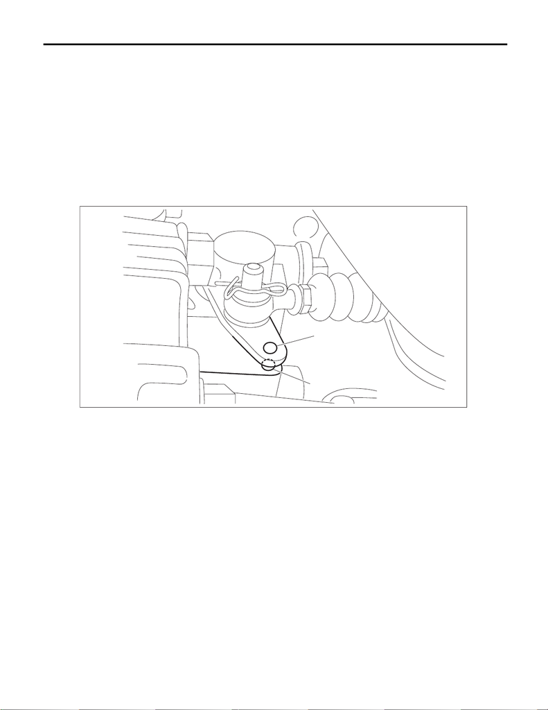

CS-119

Reverse Check Cable

CONTROL SYSTEMS

C: INSPECTION

1) Make sure the slider moves smoothly. If it does not move, adjust the reverse check cable, or check the

slider for damage. <Ref. to CS-120, ADJUSTMENT, Reverse Check Cable.>

2) Check if the gear shifts into reverse when pulling up the slider. If the gear cannot shift into reverse, adjust

the reverse check cable. <Ref. to CS-120, ADJUSTMENT, Reverse Check Cable.>

3) Check that the gear does not shift into reverse when the slider is not pulled up. If the gear shifts into re-

verse, adjust or replace the reverse check cable. <Ref. to CS-120, ADJUSTMENT, Reverse Check Cable.>

4) Make sure the hole of extension case is aligned with that of reverse check lever. If the hole positions are

not aligned, adjust the reverse check cable. <Ref. to CS-120, ADJUSTMENT, Reverse Check Cable.>

NOTE:

• Check that the M3 bolt goes through the hole of reverse check lever and can be inserted into the hole of

extension case.

• When checking visually, confirm that the gap of hole positions is 0.5 mm (0.02 in) or less.

(A) Hole of reverse check lever (B) Hole of extension case

CS-01793

(A)

(B)

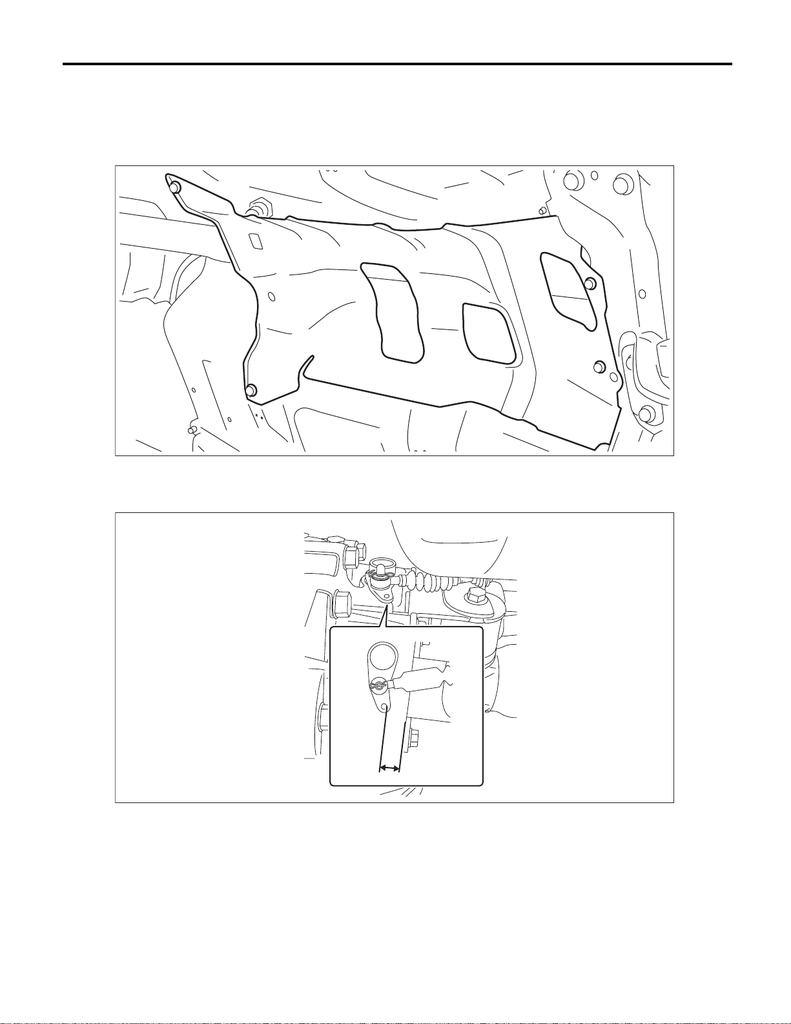

CS-120

Reverse Check Cable

CONTROL SYSTEMS

D: ADJUSTMENT

1) Disconnect the ground cable from battery.

2) Lift up the vehicle.

3) Remove the center exhaust pipe (rear). <Ref. to EX(STI)-7, REMOVAL, Center Exhaust Pipe.>

4) Remove the center exhaust cover.

5) Remove the crossmember. <Ref. to 6MT(TY85)-29, REMOVAL, Transmission Mounting System.>

6) Measure the distance “A” from the shift bracket seating face on transmission side to the hole edge of the

reverse check lever.

CS-01630

CS-01818

A

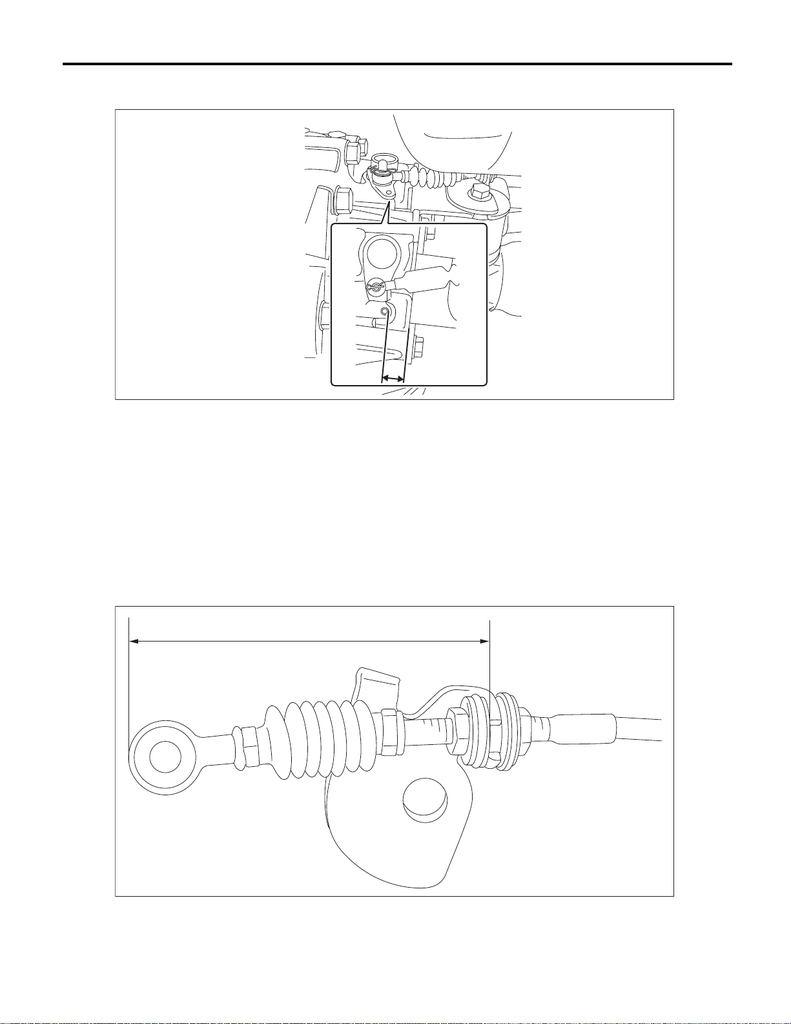

CS-121

Reverse Check Cable

CONTROL SYSTEMS

7) Measure the distance “B” from the shift bracket seating face on transmission side to the hole edge of the

extension case.

8) Calculate the following formula and determine the amount of cable adjustment.

T mm = (A – B) × 0.56

[T in = (A – B) × 0.56]

T: Amount of cable adjustment

A: Distance from the shift bracket seating face on transmission side to the hole edge of the reverse check le-

ver

B: Distance from the shift bracket seating face on transmission side to the hole edge of the extension case

NOTE:

• If the value “T” (amount of cable adjustment) is positive (+), shorten the length “C” (from cable plate edge

to reverse check cable) by using adjustment procedures.

• If the value “T” (amount of cable adjustment) is negative (–), lengthen the length “C” (from cable plate edge

to reverse check cable) by using adjustment procedures.

CS-01819

B

CS-01821

(C)

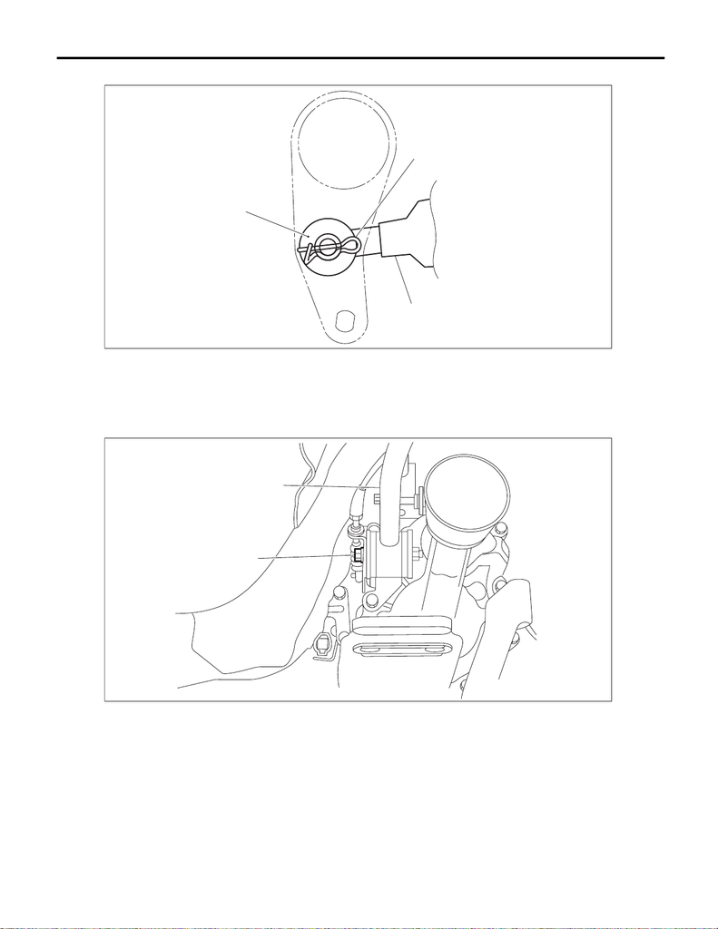

CS-122

Reverse Check Cable

CONTROL SYSTEMS

9) Remove the snap pin and washer, and separate the reverse check cable.

10) Move the transmission to the right side, and remove the stay bolts and the reverse check cable.

NOTE:

If the transmission is not moved aside, the stay bolts may contact the body and cause damage.

(A) Snap pin (B) Washer (C) Reverse check cable

(A) Stay (B) Stay bolt

CS-01788

(B)

(A)

(C)

CS-01815

(A)

(B)

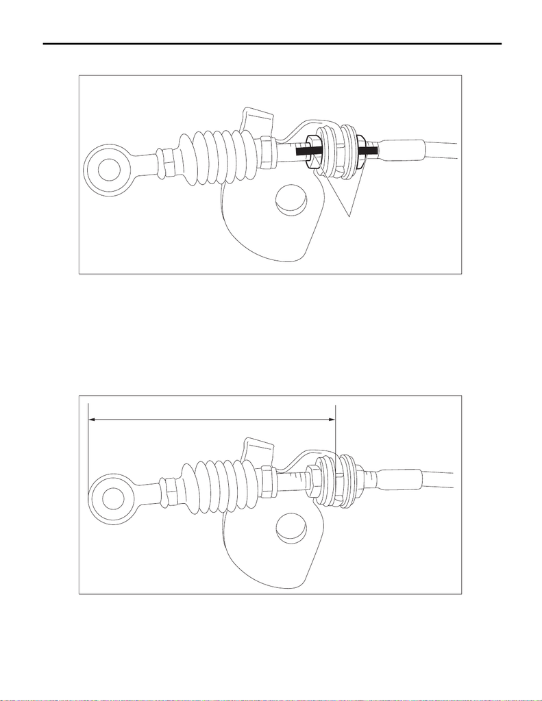

CS-123

Reverse Check Cable

CONTROL SYSTEMS

11) Check the adjustment of the reverse check cable.

(1) Add a marking on the reverse check cable.

(2) According to the value “T” (amount of cable adjustment) calculated in the step 8), turn the lock nut of

reverse check cable back and forth, then adjust the length “C” (from cable plate edge to reverse check ca-

ble).

NOTE:

• Turning the lock nut toward front of the vehicle makes the cable length shorter and toward the rear of the

vehicle the cable length longer.

• The amount of the cable adjustment by one lock nut rotation is 1 mm (0.04 in).

• Turn the lock nuts on both sides by the same adjustment amount.

(3) Tighten the lock nut.

Tightening torque:

6 N·m (0.6 kgf-m, 4.4 ft-lb)

(A) Marking

CS-01820

(A)

CS-01821

(C)

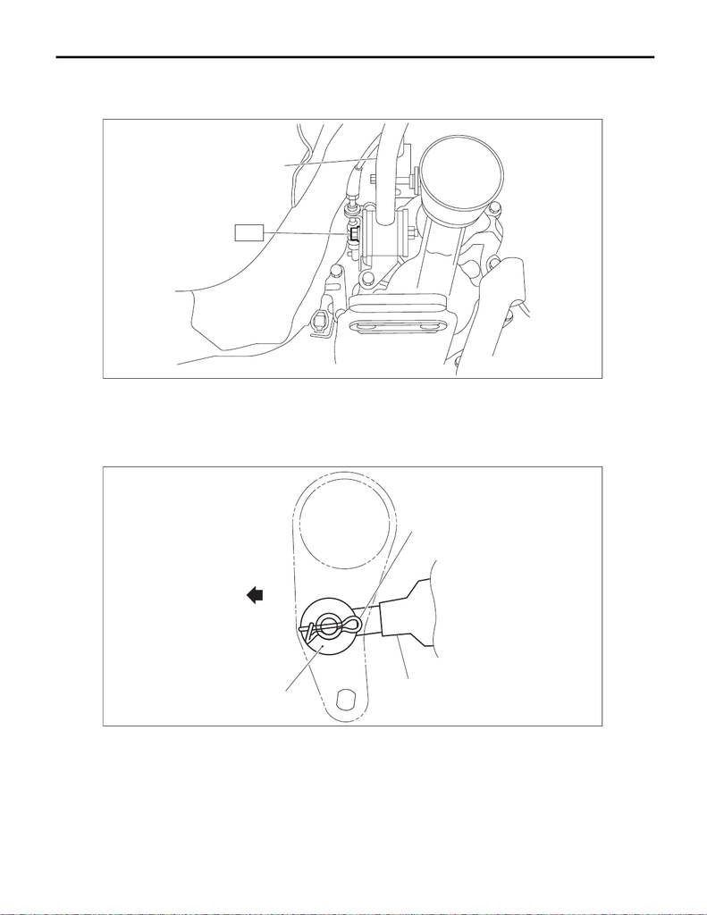

CS-124

Reverse Check Cable

CONTROL SYSTEMS

12) Move the transmission to the right side, and install the stay.

Tightening torque:

T: 32 N·m (3.3 kgf-m, 23.6 ft-lb)

13) Install the reverse check cable, washer and snap pin.

NOTE:

Make sure to point the snap pin in an appropriate direction.

(A) Stay

(A) Reverse check cable (C) Snap pin (D) Front side

(B) Washer

CS-01817

(A)

T

CS-01792

(B)

(D)

(C)

(A)

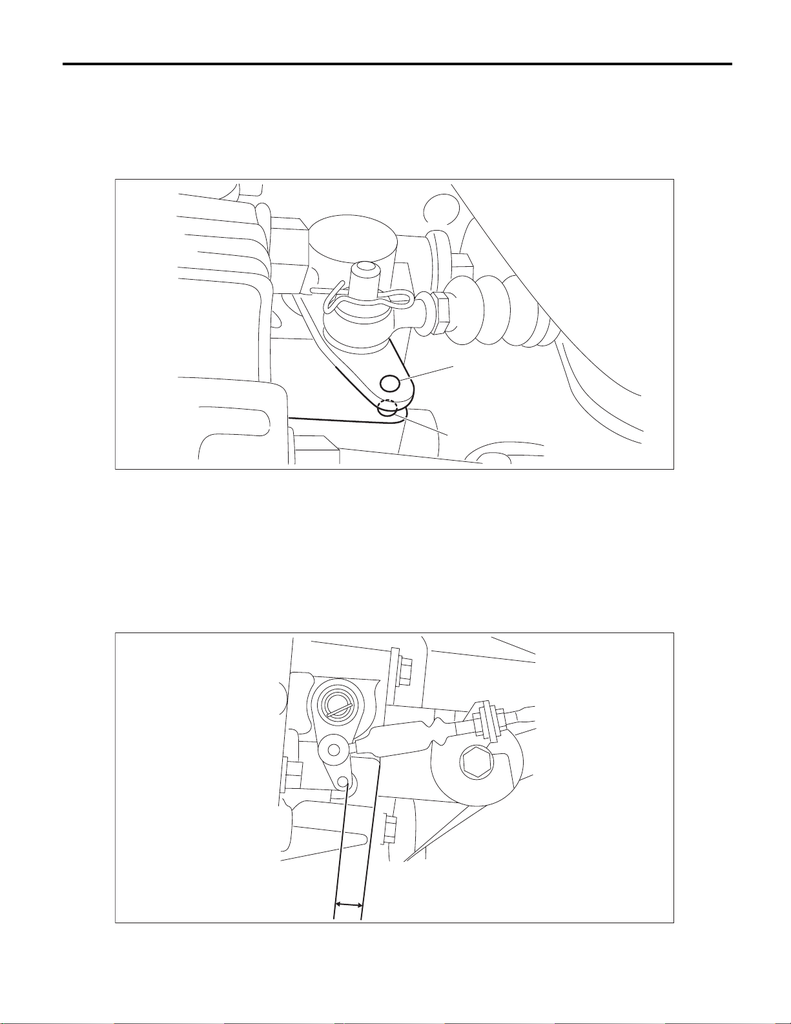

CS-125

Reverse Check Cable

CONTROL SYSTEMS

14) Make sure the hole of extension case is aligned with that of reverse check lever. If the hole positions are

not aligned, return to the step 6) and repeat the adjustment procedures of the reverse check cable.

NOTE:

• Check that the M3 bolt goes through the hole of reverse check lever and can be inserted into the hole of

extension case.

• When checking visually, confirm that the gap of hole positions is 0.5 mm (0.02 in) or less.

NOTE:

If the hole positions are not aligned after repeating the reverse check cable adjustment, adjust the cable hole

position to the reference standard.

Distance from the shift bracket seating face on transmission side to the hole edge of the reverse

check lever “A”:

Reference standard

16 mm (0.63 in)

(A) Hole of reverse check lever (B) Hole of extension case

CS-01793

(A)

(B)

CS-01822

A

[figure not shown]

CS-126

Reverse Check Cable

CONTROL SYSTEMS

15) Install the crossmember. <Ref. to 6MT(TY85)-29, INSTALLATION, Transmission Mounting System.>

16) Install the center exhaust cover.

Tightening torque:

18 N·m (1.8 kgf-m, 13.3 ft-lb)

17) Install the center exhaust pipe (rear). <Ref. to EX(STI)-8, INSTALLATION, Center Exhaust Pipe.>

18) Connect the battery ground terminal.